[figure not shown]

# **Business Problem**

AeroFit, a leading fitness equipment brand, aims to improve its treadmill recommendations to new customers by better understanding the characteristics of its existing customers. The market research team wants to identify distinct customer profiles for each treadmill model and investigate whether customer traits like age, gender, income, fitness level, and treadmill usage vary significantly across products. This analysis will enable AeroFit to provide more tailored recommendations, optimize marketing strategies, and increase sales.

# **AeroFit Dataset**

Product Purchased: The treadmill model purchased by the customer (KP281, KP481, or KP781).

Age: The age of the customer in years.

Gender: The gender of the customer (Male/Female).

Education: The number of years of formal education completed by the customer.

Marital Status: The marital status of the customer (Single or Partnered).

Usage: The average number of times per week the customer plans to use the treadmill.

Income: The customer's annual income (in dollars).

Fitness: The customer's self-rated fitness level on a scale from 1 (poor shape) to 5 (excellent shape).

Miles: The average number of miles the customer expects to walk or run on the treadmill each week.

## **Product Portfolio**:

AeroFit offers a range of treadmills tailored to different customer needs and fitness levels, allowing the brand to target various segments of the market:

- The KP281 is an entry-level treadmill that sells for $1,500.
- The KP481 is for mid-level runners that sell for $1,750.
- The KP781 treadmill is having advanced features that sell for $2,500.

By offering three distinct treadmill models, AeroFit is catering to a broad spectrum of customers, from casual users to advanced athletes, providing a product for every level of fitness and budget.

# **Libraries Utilized for Data Exploration and Analysis**

```python
import pandas as pd
import numpy as np
import matplotlib.pyplot as plt
import seaborn as sns
import warnings
warnings.filterwarnings('ignore')
```

# **Loading the Dataset for Analysis**

```python
df = pd.read_csv('https://d2beiqkhq929f0.cloudfront.net/public_assets/assets/000/001/125/original/aerofit_treadmill.csv?1639992749')
```

# **Previewing the First Five Entries of the Dataset**

```python
df.head(5)
```

|  | Product | Age | Gender | Education | MaritalStatus | Usage | Fitness | Income | Miles |
| --- | --- | --- | --- | --- | --- | --- | --- | --- | --- |
| 0 | KP281 | 18 | Male | 14 | Single | 3 | 4 | 29562 | 112 |
| 1 | KP281 | 19 | Male | 15 | Single | 2 | 3 | 31836 | 75 |
| 2 | KP281 | 19 | Female | 14 | Partnered | 4 | 3 | 30699 | 66 |
| 3 | KP281 | 19 | Male | 12 | Single | 3 | 3 | 32973 | 85 |
| 4 | KP281 | 20 | Male | 13 | Partnered | 4 | 2 | 35247 | 47 |

# **Analysing basic metrics**

```python
print(f"Total Number of rows: {df.shape[0]}")
print(f"Total Number of columns: {df.shape[1]}")
```

```
Total Number of rows: 180
Total Number of columns: 9
```

# Summary of the DataFrame Structure

```python
df.info()
```

```
<class 'pandas.core.frame.DataFrame'>
RangeIndex: 180 entries, 0 to 179
Data columns (total 9 columns):
 #   Column         Non-Null Count  Dtype
---  ------         --------------  -----
 0   Product        180 non-null    object
 1   Age            180 non-null    int64
 2   Gender         180 non-null    object
 3   Education      180 non-null    int64
 4   MaritalStatus  180 non-null    object
 5   Usage          180 non-null    int64
 6   Fitness        180 non-null    int64
 7   Income         180 non-null    int64
 8   Miles          180 non-null    int64
dtypes: int64(6), object(3)
memory usage: 12.8+ KB
```

## **Type conversion of Catagorical data**

```python
categorical_columns = ['Product', 'MaritalStatus','Gender']
df[categorical_columns] = df[categorical_columns].astype('category')
```

# Summary of the DataFrame Structure after Conversion

```python
df.info()
```

```
<class 'pandas.core.frame.DataFrame'>
RangeIndex: 180 entries, 0 to 179
Data columns (total 9 columns):
 #   Column         Non-Null Count  Dtype
---  ------         --------------  -----
 0   Product        180 non-null    category
 1   Age            180 non-null    int64
 2   Gender         180 non-null    category
 3   Education      180 non-null    int64
 4   MaritalStatus  180 non-null    category
 5   Usage          180 non-null    int64
 6   Fitness        180 non-null    int64
 7   Income         180 non-null    int64
 8   Miles          180 non-null    int64
dtypes: category(3), int64(6)
memory usage: 9.5 KB
```

# Statistical Summary

```python
df.describe()
```

|  | Age | Education | Usage | Fitness | Income | Miles |
| --- | --- | --- | --- | --- | --- | --- |
| count | 180.000000 | 180.000000 | 180.000000 | 180.000000 | 180.000000 | 180.000000 |
| mean | 28.788889 | 15.572222 | 3.455556 | 3.311111 | 53719.577778 | 103.194444 |
| std | 6.943498 | 1.617055 | 1.084797 | 0.958869 | 16506.684226 | 51.863605 |
| min | 18.000000 | 12.000000 | 2.000000 | 1.000000 | 29562.000000 | 21.000000 |
| 25% | 24.000000 | 14.000000 | 3.000000 | 3.000000 | 44058.750000 | 66.000000 |
| 50% | 26.000000 | 16.000000 | 3.000000 | 3.000000 | 50596.500000 | 94.000000 |
| 75% | 33.000000 | 16.000000 | 4.000000 | 4.000000 | 58668.000000 | 114.750000 |
| max | 50.000000 | 21.000000 | 7.000000 | 5.000000 | 104581.000000 | 360.000000 |

## Observations

- Customer Age: Most customers are around 29 years old, with ages ranging from 18 to 50. This suggests that the treadmills appeal to a relatively young to middle-aged audience.
- Education: On average, customers have around 16 years of education, indicating that they are likely college-educated.
- Treadmill Usage: Customers plan to use the treadmill about 3 to 4 times per week on average. This shows moderate to regular usage, suggesting that the products are mostly used for consistent exercise routines.
- Fitness Levels: Most customers rate their fitness as average (3 on a scale of 1 to 5). This indicates that the majority are likely fitness-conscious but not necessarily advanced athletes.
- Income: The average annual income of customers is around 54,000. This shows that AeroFit’s treadmills attract middle-income customers who have disposable income for fitness equipment.
- Miles: On average, customers expect to use the treadmill to walk or run about 103 miles per week, but this varies widely. This could indicate that some users are casual walkers, while others are more serious runners.

# **Data Sanitization**

## Examination of Missing Values by Column

```python
df.isna().sum()
```

```
Product          0
Age              0
Gender           0
Education        0
MaritalStatus    0
Usage            0
Fitness          0
Income           0
Miles            0
dtype: int64
```

### The dataset does not contain any missing values

# **Exploring Data and Conducting Non-Graphical Analysis**

## Unique Values, Count of Unique Values and Frequency of Unique Values in the Dataset.

```python
print(f"Total Number of Unique Product in the Dataset: {df['Product'].nunique()}")
print("-"*30)
print(f"Unique Values in the Dataset:\n {df['Product'].unique()}")
print("-"*30)
print(f"Available frequency Values in the Dataset:\n {df['Product'].value_counts().head(5)}")
```

```
Total Number of Unique Product in the Dataset: 3
------------------------------
Unique Values in the Dataset:
 ['KP281', 'KP481', 'KP781']
Categories (3, object): ['KP281', 'KP481', 'KP781']
------------------------------
Available frequency Values in the Dataset:
 Product
KP281    80
KP481    60
KP781    40
Name: count, dtype: int64
```

## Observation

Unique Product Portfolio:

```python
print(f"Total Number of Unique Age in the Dataset: {df['Age'].nunique()}")
print("-"*30)
print(f"Unique Values in the Dataset:\n {df['Age'].unique()}")
print("-"*30)
print(f"Available frequency Values in the Dataset:\n {df['Age'].value_counts().head(5)}")
```

```
Total Number of Unique Age in the Dataset: 32
------------------------------
Unique Values in the Dataset:
 [18 19 20 21 22 23 24 25 26 27 28 29 30 31 32 33 34 35 36 37 38 39 40 41
 43 44 46 47 50 45 48 42]
------------------------------
Available frequency Values in the Dataset:
 Age
25    25
23    18
24    12
26    12
28     9
Name: count, dtype: int64
```

```python
print(f"Total Number of Unique Gender in the Dataset: {df['Gender'].nunique()}")
print("-"*30)
print(f"Unique Values in the Dataset:\n {df['Gender'].unique()}")
print("-"*30)
print(f"Available frequency Values in the Dataset:\n {df['Gender'].value_counts().head(5)}")
```

```
Total Number of Unique Gender in the Dataset: 2
------------------------------
Unique Values in the Dataset:
 ['Male', 'Female']
Categories (2, object): ['Female', 'Male']
------------------------------
Available frequency Values in the Dataset:
 Gender
Male      104
Female     76
Name: count, dtype: int64
```

#### The higher number of Male customers indicates a potential opportunity to tailor marketing strategies to engage more female customers.

```python
print(f"Total Number of Unique Education in the Dataset: {df['Education'].nunique()}")
print("-"*30)
print(f"Unique Values in the Dataset:\n {df['Education'].unique()}")
print("-"*30)
print(f"Available frequency Values in the Dataset:\n {df['Education'].value_counts().head(5)}")
```

```
Total Number of Unique Education in the Dataset: 8
------------------------------
Unique Values in the Dataset:
 [14 15 12 13 16 18 20 21]
------------------------------
Available frequency Values in the Dataset:
 Education
16    85
14    55
18    23
15     5
13     5
Name: count, dtype: int64
```

```python
print(f"Total Number of Unique MaritalStatus in the Dataset: {df['MaritalStatus'].nunique()}")
print("-"*30)
print(f"Unique Values in the Dataset:\n {df['MaritalStatus'].unique()}")
print("-"*30)
print(f"Available frequency Values in the Dataset:\n {df['MaritalStatus'].value_counts().head(5)}")
```

```
Total Number of Unique MaritalStatus in the Dataset: 2
------------------------------
Unique Values in the Dataset:
 ['Single', 'Partnered']
Categories (2, object): ['Partnered', 'Single']
------------------------------
Available frequency Values in the Dataset:
 MaritalStatus
Partnered    107
Single        73
Name: count, dtype: int64
```

#### The higher number of Partnered customers suggests opportunities for targeted marketing to couples.

```python
print(f"Total Number of Unique Usage in the Dataset: {df['Usage'].nunique()}")
print("-"*30)
print(f"Unique Values in the Dataset:\n {df['Usage'].unique()}")
print("-"*30)
print(f"Available frequency Values in the Dataset:\n {df['Usage'].value_counts().head(5)}")
```

```
Total Number of Unique Usage in the Dataset: 6
------------------------------
Unique Values in the Dataset:
 [3 2 4 5 6 7]
------------------------------
Available frequency Values in the Dataset:
 Usage
3    69
4    52
2    33
5    17
6     7
Name: count, dtype: int64
```

#### The most frequent usage is 3 times per week, suggesting that marketing efforts can emphasize maintaining or increasing usage among customers.

```python
print(f"Total Number of Unique Fitness in the Dataset: {df['Fitness'].nunique()}")
print("-"*30)
print(f"Unique Values in the Dataset:\n {df['Fitness'].unique()}")
print("-"*30)
print(f"Available frequency Values in the Dataset:\n {df['Fitness'].value_counts().head(5)}")
```

```
Total Number of Unique Fitness in the Dataset: 5
------------------------------
Unique Values in the Dataset:
 [4 3 2 1 5]
------------------------------
Available frequency Values in the Dataset:
 Fitness
3    97
5    31
2    26
4    24
1     2
Name: count, dtype: int64
```

#### The majority of customers rate their fitness as average (3), indicating potential for marketing strategies focused on improving fitness levels.

```python
print(f"Total Number of Unique Income in the Dataset: {df['Income'].nunique()}")
print("-"*30)
print(f"Unique Values in the Dataset:\n {df['Income'].unique()}")
print("-"*30)
print(f"Available frequency Values in the Dataset:\n {df['Income'].value_counts().head(5)}")
```

```
Total Number of Unique Income in the Dataset: 62
------------------------------
Unique Values in the Dataset:
 [ 29562  31836  30699  32973  35247  37521  36384  38658  40932  34110
  39795  42069  44343  45480  46617  48891  53439  43206  52302  51165
  50028  54576  68220  55713  60261  67083  56850  59124  61398  57987
  64809  47754  65220  62535  48658  54781  48556  58516  53536  61006
  57271  52291  49801  62251  64741  70966  75946  74701  69721  83416
  88396  90886  92131  77191  52290  85906 103336  99601  89641  95866
 104581  95508]
------------------------------
Available frequency Values in the Dataset:
 Income
45480    14
52302     9
46617     8
54576     8
53439     8
Name: count, dtype: int64
```

```python
print(f"Total Number of Unique Miles in the Dataset: {df['Miles'].nunique()}")
print("-"*30)
print(f"Unique Values in the Dataset:\n {df['Miles'].unique()}")
print("-"*30)
print(f"Available frequency Values in the Dataset:\n {df['Miles'].value_counts().head(5)}")
```

```
Total Number of Unique Miles in the Dataset: 37
------------------------------
Unique Values in the Dataset:
 [112  75  66  85  47 141 103  94 113  38 188  56 132 169  64  53 106  95
 212  42 127  74 170  21 120 200 140 100  80 160 180 240 150 300 280 260
 360]
------------------------------
Available frequency Values in the Dataset:
 Miles
85    27
95    12
66    10
75    10
47     9
Name: count, dtype: int64
```

```python
print(f"Oldest consumer in the dataset: {df['Age'].max()}")
print(f"Youngest consumer in the dataset: {df['Age'].min()}")
```

```
Oldest consumer in the dataset: 50
Youngest consumer in the dataset: 18
```

```python
print(f"Longest Run in the dataset: {df['Miles'].max()}")
print(f"Shortest Run in the dataset: {df['Miles'].min()}")
```

```
Longest Run in the dataset: 360
Shortest Run in the dataset: 21
```

```python
print(f"Highest income in the dataset: {df['Income'].max()}")
print(f"Lowest income in the dataset: {df['Income'].min()}")
print(f"Average income in the dataset: {df['Income'].mean()}")
print(f"Income standard deviation in the dataset: {df['Income'].std()}")
```

```
Highest income in the dataset: 104581
Lowest income in the dataset: 29562
Average income in the dataset: 53719.57777777778
Income standard deviation in the dataset: 16506.68422623862
```

#### **Treadmill Preferences for Highest and Lowest Income Consumer**

```python
df.sort_values('Income', ascending=True)[['Product', 'Income']].head(3)
```

|  | Product | Income |
| --- | --- | --- |
| 0 | KP281 | 29562 |
| 2 | KP281 | 30699 |
| 1 | KP281 | 31836 |

```python
df.sort_values('Income', ascending=False)[['Product', 'Income']].head(3)
```

|  | Product | Income |
| --- | --- | --- |
| 174 | KP781 | 104581 |
| 178 | KP781 | 104581 |
| 168 | KP781 | 103336 |

## Observations:

- **Lowest Income Users**: All three lowest income entries are associated with the KP281 treadmill, which is the entry-level model priced at $1,500. This indicates that budget-conscious consumers prioritize affordable options, likely due to financial constraints.
- **Highest Income Users**:The highest income entries are dominated by the KP781 treadmill, priced at $2,500, which offers advanced features. This suggests that affluent customers are willing to invest in premium fitness equipment, reflecting a preference for quality and advanced functionalities.

let's create new column before analys

```python
bin_range1 = [17,25,35,45,float('inf')]
bin_labels1 = ['Young Adults', 'Adults', 'Middle Aged Adults', 'Elder']
df['age_group'] = pd.cut(df['Age'],bins = bin_range1,labels = bin_labels1)

bin_range2 = [0,12,15,float('inf')]
bin_labels2 = ['Primary Education', 'Secondary Education', 'Higher Education']
df['edu_group'] = pd.cut(df['Education'],bins = bin_range2,labels = bin_labels2)

bin_range3 = [0,40000,60000,80000,float('inf')]
bin_labels3 = ['Low Income','Moderate Income','High Income','Very High Income']
df['income_group'] = pd.cut(df['Income'],bins = bin_range3,labels = bin_labels3)
```

# **Data Exploration and Conducting Graphical Analysis**

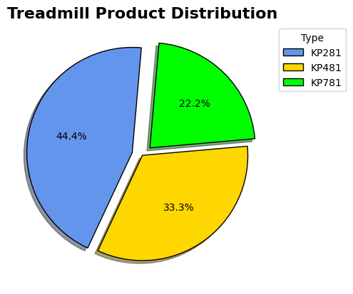

```python
types = df.Product.value_counts()
plt.pie(types,  autopct='%1.1f%%' , colors = ['cornflowerblue','gold','lime'],
          startangle=85,
    explode=(0.1, 0,0.1),
    shadow=True,
    wedgeprops={'edgecolor': 'black'})
plt.legend(types.index, title="Type", loc="upper left", bbox_to_anchor=(1, 0, 0.5, 1))
plt.title('Treadmill Product Distribution',fontsize=16, fontweight='bold')
plt.show()
```

### **Observations**

KP281 is the most popular treadmill model, accounting for 44.4% of sales.

KP481 is the second most popular model, with 33.3% of sales.

KP781 is the least popular model, representing 22.2% of sales.

Overall, the pie chart indicates a clear preference for the KP281 model among customers. This could be due to various factors such as price, features, or perceived value.

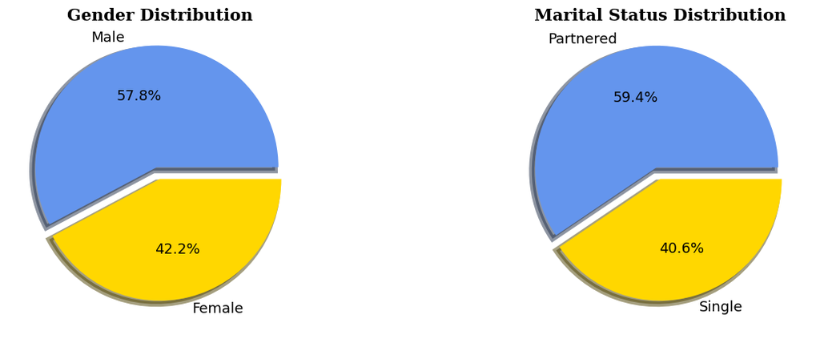

```python
fig, ax = plt.subplots(1, 2, figsize=(15, 5))
ax[0].pie(df['Gender'].value_counts().values,labels = df['Gender'].value_counts().index,autopct = '%.1f%%',
        shadow = True,colors = ['cornflowerblue','gold'],wedgeprops = {'linewidth': 5},textprops={'fontsize': 13, 'color': 'black'},
              explode=(0.1, 0),)
ax[0].set_title('Gender Distribution',{'font':'serif', 'size':15,'weight':'bold'})
ax[1].pie(df['MaritalStatus'].value_counts().values,labels = df['MaritalStatus'].value_counts().index,autopct = '%.1f%%',
        shadow = True,colors = ['cornflowerblue','gold'],wedgeprops = {'linewidth': 5},textprops={'fontsize': 13, 'color': 'black'},explode=(0.1, 0))
ax[1].set_title('Marital Status Distribution',{'font':'serif', 'size':15,'weight':'bold'})

plt.show()
```

### Observations:

- Gender Distribution:
  - Male: 57.8% of customers are male.
  - Female: 42.2% of customers are female.
- Marital Status Distribution:
  - Partnered: 59.4% of customers are partnered.
  - Single: 40.6% of customers are single.

Overall, the pie charts indicate a slight majority of male customers and partnered individuals in the dataset. This information can be useful for understanding the target customer base and tailoring marketing strategies accordingly. For example, Aerofit could consider creating targeted campaigns specifically for male customers or partnered individuals.

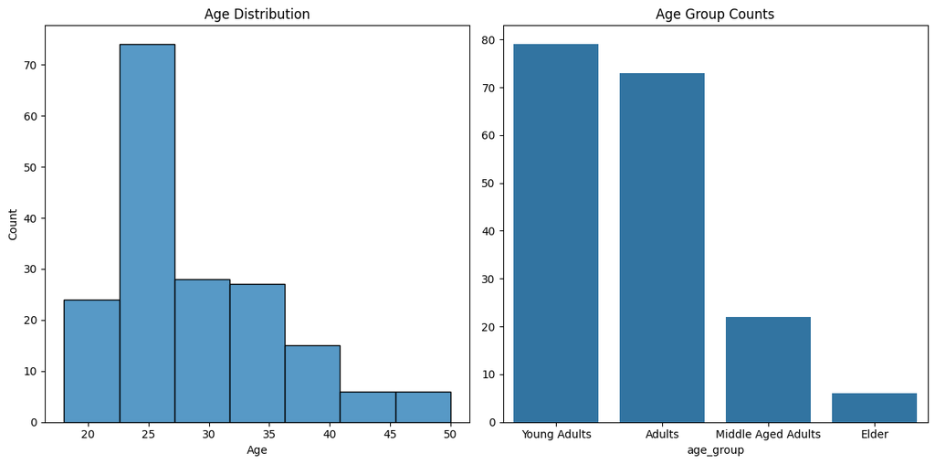

```python
fig, ax = plt.subplots(1, 2, figsize=(12, 6))

sns.histplot(df['Age'], bins=7, ax=ax[0])
ax[0].set_title('Age Distribution')
sns.barplot(x=df['age_group'].value_counts().index,
            y=df['age_group'].value_counts().values,
            ax=ax[1])
ax[1].set_title('Age Group Counts')

plt.tight_layout()
plt.show()
```

### Observations:

Age Distribution:

Age Group Counts:

- Young Adults: The largest group of customers is in the "Young Adults" category, followed by "Adults."
- Middle-Aged Adults: There is a smaller number of customers in the "Middle-Aged Adults" category.
- Elder: The smallest group of customers is in the "Elder" category.

Overall, the plots suggest that Aerofit's customer base is primarily made up of young adults. This information can be valuable for targeting marketing efforts and developing products that cater to the needs and preferences of this demographic.

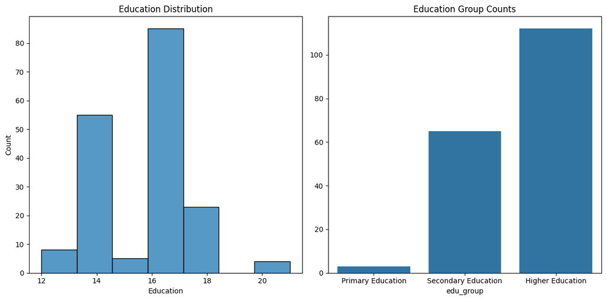

```python
fig, ax = plt.subplots(1, 2, figsize=(12, 6))
sns.histplot(df['Education'], bins=7, ax=ax[0])
ax[0].set_title('Education Distribution')
sns.barplot(x=df['edu_group'].value_counts().index,
            y=df['edu_group'].value_counts().values,
            ax=ax[1])
ax[1].set_title('Education Group Counts')
plt.tight_layout()
```

### **Observations**

Education Distribution:

- The distribution of education levels is skewed to the right, indicating that there are more customers with higher education levels.
- The majority of customers have completed 16 years of education.
- There is a smaller number of customers with lower education levels.

Education Group Counts:

Overall, the plots suggest that Aerofit's customer base is well-educated, with a majority of customers having completed secondary or higher education. This information can be valuable for targeting marketing efforts and developing products that cater to the needs of educated customers.

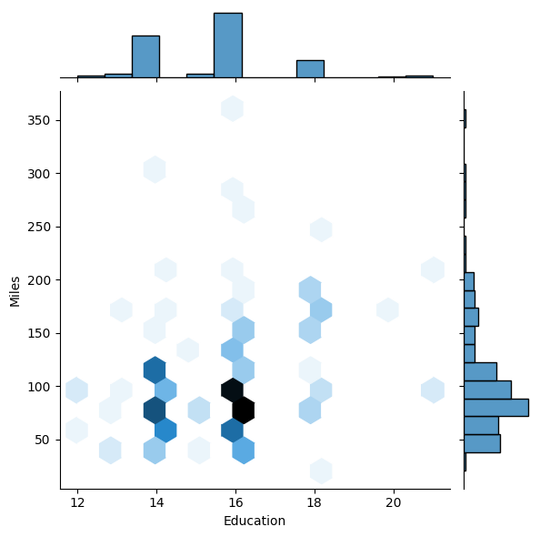

```python
sns.jointplot(x="Education", y="Miles", data=df, kind='hex')
plt.show()
```

### Observations:

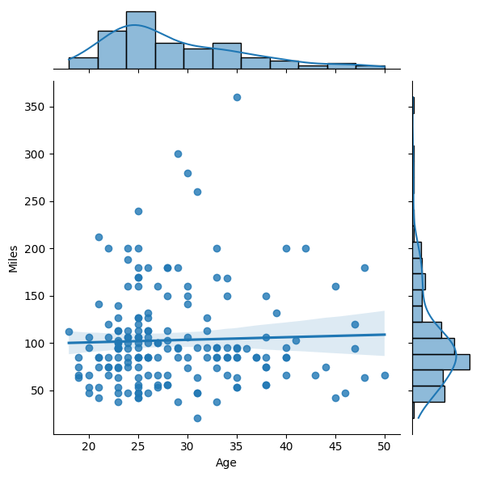

```python
sns.jointplot(x="Age", y="Miles", data=df, kind='reg')
plt.show()
```

### Observations:

Key Observations:

Business Insights:

- Target Market: Aerofit could focus on marketing their treadmills to customers in different age groups. For example, they could emphasize the benefits of treadmill use for improving fitness and overall health for older customers. Product Features: The company could consider adding features that appeal to customers at different stages of life. For example, they could offer programs specifically designed for older customers or for younger customers who are just starting their fitness journey.
- Pricing Strategy: Aerofit could adjust their pricing strategy based on the age of their target customers. For example, they could offer discounts to older customers or students.

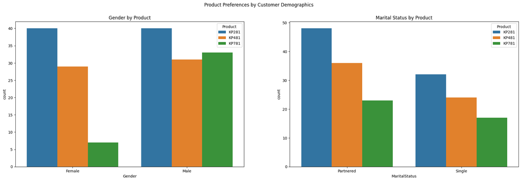

```python
fig, ax = plt.subplots(1, 2, figsize=(24, 7))
sns.countplot(data=df, x='Gender', ax=ax[0], hue='Product')
sns.countplot(data=df, x='MaritalStatus', ax=ax[1], hue='Product')
ax[0].set_title('Gender by Product')
ax[1].set_title('Marital Status by Product')
plt.suptitle('Product Preferences by Customer Demographics')
plt.show()
```

### **Observations**

#### Gender by Product:

- KP281: Has a relatively equal distribution among males and females.
- KP481: Has a slightly higher proportion of male customers.
- KP781: Has a significantly higher proportion of male customers.

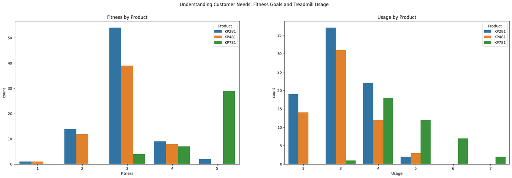

```python
fig, ax = plt.subplots(1, 2, figsize=(24, 7))
sns.countplot(data=df, x='Fitness',hue='Product',ax=ax[0])
sns.countplot(data=df, x='Usage',hue='Product',ax=ax[1])
ax[0].set_title('Fitness by Product')
ax[1].set_title('Usage by Product')
plt.suptitle('Understanding Customer Needs: Fitness Goals and Treadmill Usage')
plt.show()
```

### **Observations**

```python
pd.crosstab(df['Gender'],
            df['Product'],
            margins=True,)
```

| Product Gender | KP281 | KP481 | KP781 | All |
| --- | --- | --- | --- | --- |
| Female | 40 | 29 | 7 | 76 |
| Male | 40 | 31 | 33 | 104 |
| All | 80 | 60 | 40 | 180 |

```python
crosstab=pd.crosstab(df['Gender'],
            df['Product'],
            margins=True,
            normalize='index')
x=crosstab.columns.tolist()
y=crosstab.loc['All']*100
y=y.tolist()
```

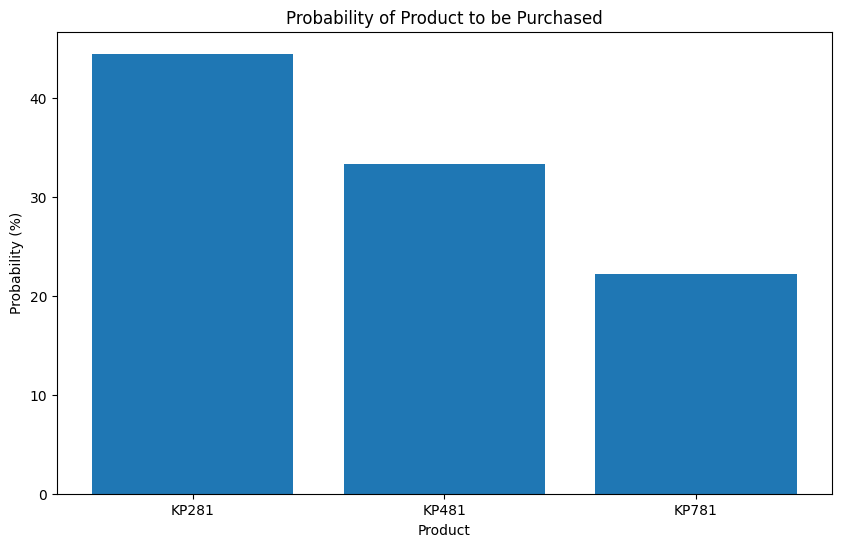

```python
plt.figure(figsize=(10, 6))
plt.title('Probability of Product to be Purchased')
plt.bar(x, y)
plt.xlabel('Product')
plt.ylabel('Probability (%)')
plt.show()
```

### **Observation**

KP281 has the highest probability of being purchased by customers, followed by KP481 and then KP781.

KP781 has the lowest probability of being purchased.

**All this could be due to several Factors**:

- Price: KP281 may be the most affordable option, making it more attractive to budget-conscious customers.
- Durability: KP281 may be perceived as being more durable or reliable than the other models, which could influence customer purchasing decisions.
- Features: KP781 may have advanced features that are not as important to many customers, or it may be priced higher than KP281 and KP481.

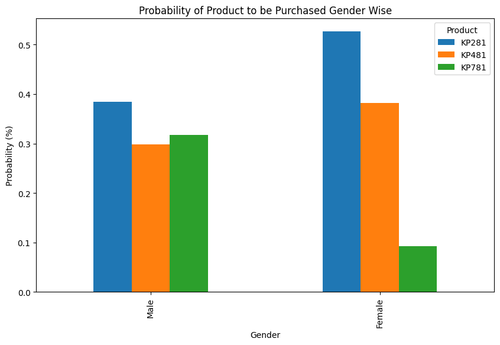

```python
crosstab.loc[['Male','Female']].plot(kind='bar', figsize=(10, 6))
plt.title('Probability of Product to be Purchased Gender Wise')
plt.xlabel('Gender')
plt.ylabel('Probability (%)')
plt.show()
```

### **Observations**

```python
crosstab=pd.crosstab(df['income_group'],
            df['Product'],
            margins=True,
            normalize='index')
x=crosstab.columns.tolist()
y=crosstab.loc['All']*100
y=y.tolist()
crosstab
```

| Product income_group | KP281 | KP481 | KP781 |
| --- | --- | --- | --- |
| Low Income | 0.718750 | 0.281250 | 0.000000 |
| Moderate Income | 0.481132 | 0.415094 | 0.103774 |
| High Income | 0.260870 | 0.304348 | 0.434783 |
| Very High Income | 0.000000 | 0.000000 | 1.000000 |
| All | 0.444444 | 0.333333 | 0.222222 |

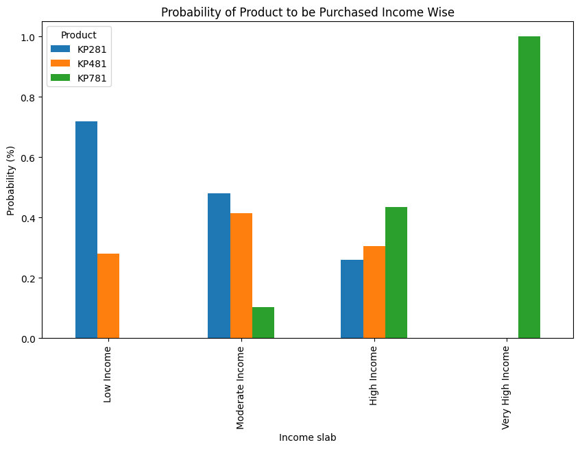

```python
crosstab.loc[['Low Income','Moderate Income','High Income','Very High Income']].plot(kind='bar', figsize=(10, 6))
plt.title('Probability of Product to be Purchased Income Wise')
plt.xlabel('Income slab')
plt.ylabel('Probability (%)')
plt.show()
```

#### Observations:

```python
crosstab=pd.crosstab(df['edu_group'],
            df['Product'],
            margins=True,
            normalize='index')
x=crosstab.columns.tolist()
y=crosstab.loc['All']*100
y=y.tolist()
crosstab
```

| Product edu_group | KP281 | KP481 | KP781 |
| --- | --- | --- | --- |
| Primary Education | 0.666667 | 0.333333 | 0.000000 |
| Secondary Education | 0.569231 | 0.400000 | 0.030769 |
| Higher Education | 0.366071 | 0.294643 | 0.339286 |
| All | 0.444444 | 0.333333 | 0.222222 |

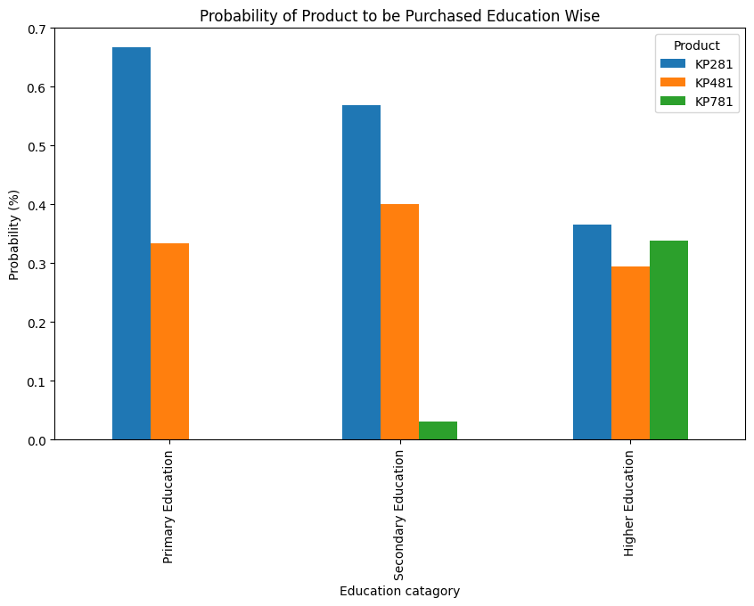

```python
crosstab.loc[['Primary Education','Secondary Education','Higher Education']].plot(kind='bar', figsize=(10, 6))
plt.title('Probability of Product to be Purchased Education Wise')
plt.xlabel('Education catagory')
plt.ylabel('Probability (%)')
plt.show()
```

### Observations:

```python
crosstab=pd.crosstab(df['Fitness'],
            df['Product'],
            margins=True,
            normalize='index')
x=crosstab.columns.tolist()
y=crosstab.loc['All']*100
y=y.tolist()
crosstab
```

| Product Fitness | KP281 | KP481 | KP781 |
| --- | --- | --- | --- |
| 1 | 0.500000 | 0.500000 | 0.000000 |
| 2 | 0.538462 | 0.461538 | 0.000000 |
| 3 | 0.556701 | 0.402062 | 0.041237 |
| 4 | 0.375000 | 0.333333 | 0.291667 |
| 5 | 0.064516 | 0.000000 | 0.935484 |
| All | 0.444444 | 0.333333 | 0.222222 |

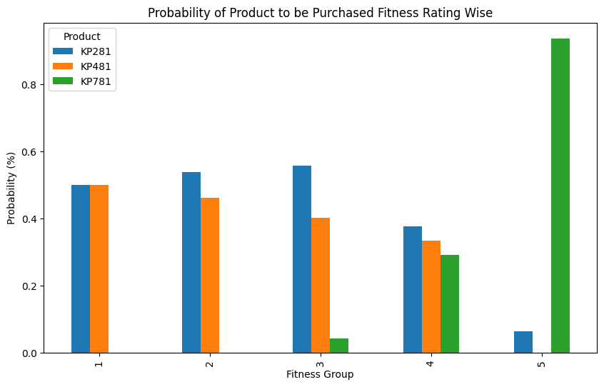

```python
crosstab.iloc[0:5].plot(kind='bar', figsize=(10, 6))
plt.title('Probability of Product to be Purchased Fitness Rating Wise')
plt.xlabel('Fitness Group')
plt.ylabel('Probability (%)')
plt.show()
```

### Observations:

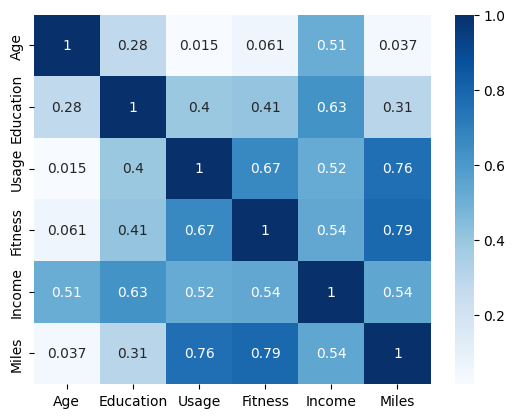

```python
df_corr = df.select_dtypes(include=[np.number])
sns.heatmap(df_corr.corr(), cmap="Blues", annot=True)
plt.show()
```

### **Observations**

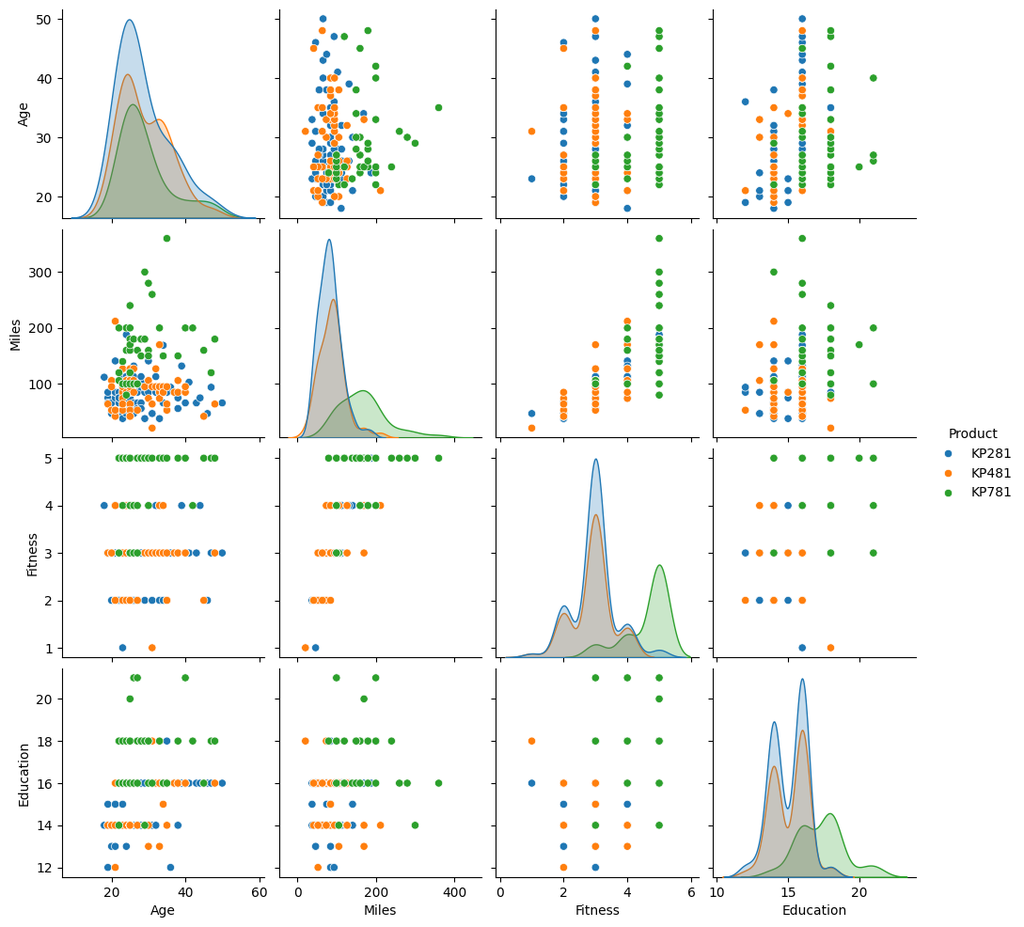

```python
sns.pairplot(data=df,hue='Product',vars=['Age', 'Miles', 'Fitness','Education'])
plt.show()
```

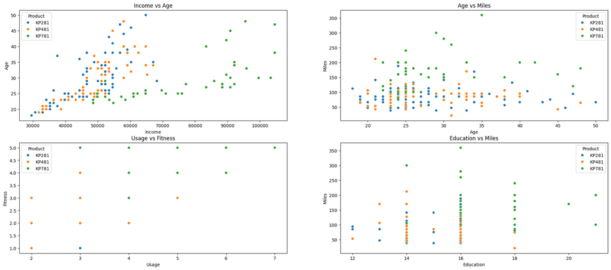

```python
fig, ax = plt.subplots(2, 2, figsize=(24, 10))
sns.scatterplot(x= 'Income', y= 'Age', data = df,ax=ax[0,0],hue='Product')
ax[0,0].set_title('Income vs Age')
sns.scatterplot(x= 'Age', y= 'Miles', data = df,ax=ax[0,1],hue='Product')
ax[0,1].set_title('Age vs Miles')
sns.scatterplot(x= 'Usage', y= 'Fitness', data = df,ax=ax[1,0],hue='Product')
ax[1,0].set_title('Usage vs Fitness')
sns.scatterplot(x= 'Education', y= 'Miles', data = df,ax=ax[1,1],hue='Product')
ax[1,1].set_title('Education vs Miles')
plt.show()
```

### Observation

#### Income vs. Age:

There is a weak positive correlation between income and age, suggesting that older customers tend to have higher incomes. However, there is also a significant amount of variation around this trend, indicating that income is not solely determined by age.

#### Usage vs. Fitness:

There is a moderate positive correlation between usage and fitness, suggesting that customers who use the treadmill more frequently tend to have higher self-rated fitness levels. However, there are also some outliers, indicating that there may be other factors influencing fitness levels.

#### Education vs. Miles:

There is a weak positive correlation between education and miles walked, suggesting that customers with higher education levels tend to walk or run more miles. However, this relationship is not very strong, and there is a significant amount of variation around the trend.

## Understanding Distribution and Identifying Outliers

## Box plot-Visiual Analysis Before Outlier treament

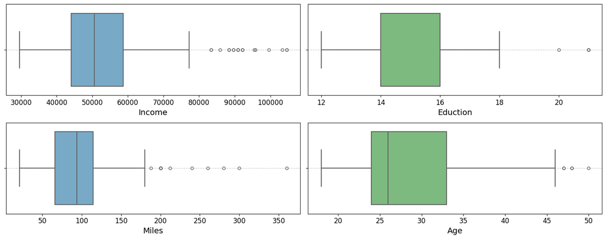

```python
fig, ax = plt.subplots(2, 2, figsize=(15, 6))
sns.boxplot(data=df, x='Income', ax=ax[0,0], palette='Blues', fliersize=5, linewidth=1.5)
ax[0,0].set_xlabel('Income', fontsize=14)
ax[0,0].tick_params(axis='x', labelsize=12)
ax[0,0].tick_params(axis='y', labelsize=12)
ax[0,0].grid(axis='y', linestyle='--', alpha=0.7)

sns.boxplot(data=df, x='Education', ax=ax[0,1], palette='Greens', fliersize=5, linewidth=1.5)
ax[0,1].set_xlabel('Eduction', fontsize=14)
ax[0,1].tick_params(axis='x', labelsize=12)
ax[0,1].tick_params(axis='y', labelsize=12)
ax[0,1].grid(axis='y', linestyle='--', alpha=0.7)

sns.boxplot(data=df, x='Miles', ax=ax[1,0], palette='Blues', fliersize=5, linewidth=1.5)
ax[1,0].set_xlabel('Miles', fontsize=14)
ax[1,0].tick_params(axis='x', labelsize=12)
ax[1,0].tick_params(axis='y', labelsize=12)
ax[1,0].grid(axis='y', linestyle='--', alpha=0.7)

sns.boxplot(data=df, x='Age', ax=ax[1,1], palette='Greens', fliersize=5, linewidth=1.5)
ax[1,1].set_xlabel('Age', fontsize=14)
ax[1,1].tick_params(axis='x', labelsize=12)
ax[1,1].tick_params(axis='y', labelsize=12)
ax[1,1].grid(axis='y', linestyle='--', alpha=0.7)
plt.tight_layout()
plt.show()
```

### Observation

#### Income:

- The distribution of income is skewed to the right, indicating that there are a smaller number of customers with higher incomes compared to lower incomes.
- There are several outliers on the right side of the box plot, suggesting that a few customers have significantly higher incomes than the majority of the sample.

#### Education:

- The distribution of education is relatively symmetrical, with a slight skew to the right.
- There are a few outliers on the right side of the box plot, indicating that a small number of customers have higher education levels than the majority of the sample.

#### Miles:

- The distribution of miles is skewed to the right, indicating that there are a smaller number of customers who walk or run significantly more miles than the average.
- There are several outliers on the right side of the box plot, suggesting that a few customers are significantly more active than the majority of the sample.

#### Age

- The distribution of age is skewed to the right, indicating that there are a smaller number of older customers compared to younger customers.

```python
Q1 = df['Income'].quantile(0.25)
Q3 = df['Income'].quantile(0.75)
IQR = Q3 - Q1
Income_lower_bound = Q1 - 1.5 * IQR
Income_upper_bound = Q3 + 1.5 * IQR
print(f"Income Upper Bound: {Income_upper_bound}, Income Lower Bound: {Income_lower_bound}")
is_outlier_upper = Income_upper_bound < df['Income'].max()
is_outlier_lower = Income_lower_bound > df['Income'].min()
print(f"Is the value exceeding the upper bound limit? {is_outlier_upper}")
print(f"Is the value falling below the lower bound limit? {is_outlier_lower}.")
print('---'*30)
Q1 = df['Education'].quantile(0.25)
Q3 = df['Education'].quantile(0.75)
IQR = Q3 - Q1
Education_lower_bound = Q1 - 1.5 * IQR
Education_upper_bound = Q3 + 1.5 * IQR
print(f"Education Upper Bound: {Education_upper_bound}, Education Lower Bound: {Education_lower_bound}")
is_outlier_upper = Education_upper_bound < df['Education'].max()
is_outlier_lower = Education_lower_bound > df['Education'].min()
print(f"Is the value exceeding the upper bound limit? {is_outlier_upper}")
print(f"Is the value falling below the lower bound limit? {is_outlier_lower}.")
print('---'*30)
Q1 = df['Miles'].quantile(0.25)
Q3 = df['Miles'].quantile(0.75)
IQR = Q3 - Q1
Miles_lower_bound = Q1 - 1.5 * IQR
Miles_upper_bound = Q3 + 1.5 * IQR
print(f"Miles Upper Bound: {Miles_upper_bound}, Miles Lower Bound: {Miles_lower_bound}")
is_outlier_upper = Miles_upper_bound < df['Miles'].max()
is_outlier_lower = Miles_lower_bound > df['Miles'].min()
print(f"Is the value exceeding the upper bound limit? {is_outlier_upper}")
print(f"Is the value falling below the lower bound limit? {is_outlier_lower}.")
print('---'*30)
Q1 = df['Age'].quantile(0.25)
Q3 = df['Age'].quantile(0.75)
IQR = Q3 - Q1
Age_lower_bound = Q1 - 1.5 * IQR
Age_upper_bound = Q3 + 1.5 * IQR
print(f"Age Upper Bound: {Age_upper_bound}, Age Lower Bound: {Age_lower_bound}")
is_outlier_upper = Age_upper_bound < df['Age'].max()
is_outlier_lower = Age_lower_bound > df['Age'].min()
print(f"Is the value exceeding the upper bound limit? {is_outlier_upper}")
print(f"Is the value falling below the lower bound limit? {is_outlier_lower}.")
```

```
Income Upper Bound: 80581.875, Income Lower Bound: 22144.875
Is the value exceeding the upper bound limit? True
Is the value falling below the lower bound limit? False.
------------------------------------------------------------------------------------------
Education Upper Bound: 19.0, Education Lower Bound: 11.0
Is the value exceeding the upper bound limit? True
Is the value falling below the lower bound limit? False.
------------------------------------------------------------------------------------------
Miles Upper Bound: 187.875, Miles Lower Bound: -7.125
Is the value exceeding the upper bound limit? True
Is the value falling below the lower bound limit? False.
------------------------------------------------------------------------------------------
Age Upper Bound: 46.5, Age Lower Bound: 10.5
Is the value exceeding the upper bound limit? True
Is the value falling below the lower bound limit? False.
```

### Observations:

#### Education:

- Upper Bound Exceeded: The maximum education value (21) exceeds the upper bound of 19.0, indicating that there is at least one outlier in the education data.
- Lower Bound Not Exceeded: The minimum education value is above the lower bound, indicating that there are no outliers below the lower bound.

#### Miles:

- Upper Bound Exceeded: The maximum miles value (360) exceeds the upper bound of 187.875, indicating that there is at least one outlier in the miles data.
- Lower Bound Not Exceeded: The minimum miles value is above the lower bound, indicating that there are no outliers below the lower bound.

#### Age:

- Upper Bound Exceeded: The maximum age value (50) exceeds the upper bound of 46.5, indicating that there is at least one outlier in the age data.
- Lower Bound Not Exceeded: The minimum age value is above the lower bound, indicating that there are no outliers below the lower bound.

```python
clean_Income_data = df[(df['Income'] >= Income_lower_bound) & (df['Income'] <= Income_upper_bound)]
clean_Education_data = df[(df['Education'] >= Education_lower_bound) & (df['Education'] <= Education_upper_bound)]
clean_Miles_data = df[(df['Miles'] >= Miles_lower_bound) & (df['Miles'] <= Miles_upper_bound)]
clean_Age_shows_data = df[(df['Age'] >= Age_lower_bound) & (df['Age'] <= Age_upper_bound)]
```

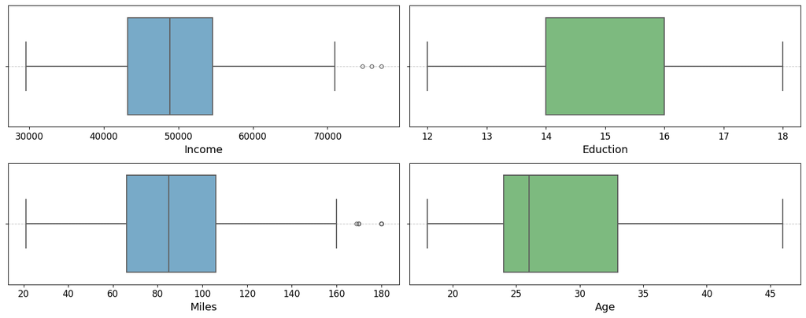

```python
fig, ax = plt.subplots(2, 2, figsize=(15, 6))
sns.boxplot(data=clean_Income_data, x='Income', ax=ax[0,0], palette='Blues', fliersize=5, linewidth=1.5)
ax[0,0].set_xlabel('Income', fontsize=14)
ax[0,0].tick_params(axis='x', labelsize=12)
ax[0,0].tick_params(axis='y', labelsize=12)
ax[0,0].grid(axis='y', linestyle='--', alpha=0.7)

sns.boxplot(data=clean_Education_data, x='Education', ax=ax[0,1], palette='Greens', fliersize=5, linewidth=1.5)
ax[0,1].set_xlabel('Eduction', fontsize=14)
ax[0,1].tick_params(axis='x', labelsize=12)
ax[0,1].tick_params(axis='y', labelsize=12)
ax[0,1].grid(axis='y', linestyle='--', alpha=0.7)

sns.boxplot(data=clean_Miles_data, x='Miles', ax=ax[1,0], palette='Blues', fliersize=5, linewidth=1.5)
ax[1,0].set_xlabel('Miles', fontsize=14)
ax[1,0].tick_params(axis='x', labelsize=12)
ax[1,0].tick_params(axis='y', labelsize=12)
ax[1,0].grid(axis='y', linestyle='--', alpha=0.7)

sns.boxplot(data=clean_Age_shows_data, x='Age', ax=ax[1,1], palette='Greens', fliersize=5, linewidth=1.5)
ax[1,1].set_xlabel('Age', fontsize=14)
ax[1,1].tick_params(axis='x', labelsize=12)
ax[1,1].tick_params(axis='y', labelsize=12)
ax[1,1].grid(axis='y', linestyle='--', alpha=0.7)
plt.tight_layout()
plt.show()
```

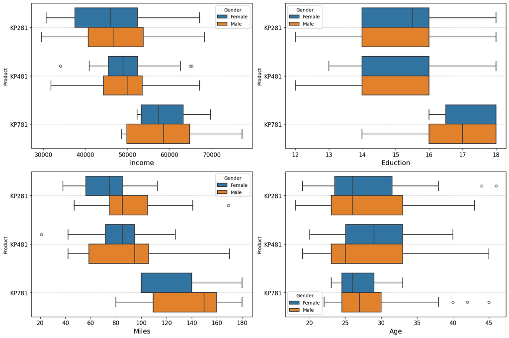

```python
fig, ax = plt.subplots(2, 2, figsize=(15, 10))
sns.boxplot(data=clean_Income_data, x='Income', ax=ax[0,0], fliersize=5, linewidth=1.5,y='Product',hue='Gender')
ax[0,0].set_xlabel('Income', fontsize=14)
ax[0,0].tick_params(axis='x', labelsize=12)
ax[0,0].tick_params(axis='y', labelsize=12)
ax[0,0].grid(axis='y', linestyle='--', alpha=0.7)

sns.boxplot(data=clean_Education_data, x='Education', ax=ax[0,1], fliersize=5, linewidth=1.5,y='Product',hue='Gender')
ax[0,1].set_xlabel('Eduction', fontsize=14)
ax[0,1].tick_params(axis='x', labelsize=12)
ax[0,1].tick_params(axis='y', labelsize=12)
ax[0,1].grid(axis='y', linestyle='--', alpha=0.7)

sns.boxplot(data=clean_Miles_data, x='Miles', ax=ax[1,0], fliersize=5, linewidth=1.5,y='Product',hue='Gender')
ax[1,0].set_xlabel('Miles', fontsize=14)
ax[1,0].tick_params(axis='x', labelsize=12)
ax[1,0].tick_params(axis='y', labelsize=12)
ax[1,0].grid(axis='y', linestyle='--', alpha=0.7)

sns.boxplot(data=clean_Age_shows_data, x='Age', ax=ax[1,1], fliersize=5, linewidth=1.5,y='Product',hue='Gender')
ax[1,1].set_xlabel('Age', fontsize=14)
ax[1,1].tick_params(axis='x', labelsize=12)
ax[1,1].tick_params(axis='y', labelsize=12)
ax[1,1].grid(axis='y', linestyle='--', alpha=0.7)
plt.tight_layout()
plt.show()
```

### Observations:

#### Income by Product:

- KP281: Customers who purchased KP281 have a slightly lower median income compared to those who purchased KP481 and KP781.
- KP481: Customers who purchased KP481 have a higher median income compared to those who purchased KP281, but lower than those who purchased KP781.
- KP781: Customers who purchased KP781 have the highest median income, suggesting it may be a more premium product.

#### Education by Product:

- KP281: Customers who purchased KP281 have a slightly lower median education level compared to those who purchased KP481 and KP781.
- KP481: Customers who purchased KP481 have a slightly higher median education level compared to those who purchased KP281, but lower than those who purchased KP781.
- KP781: Customers who purchased KP781 have the highest median education level, suggesting it may be more popular among customers with higher education.

## Customer Profiling

### Business Insights

#### Product Purchase Trends:

- KP281 is the most popular product, likely due to its affordability and durability, while KP781 is less favored, potentially due to its higher price and advanced features .

#### Usage and Fitness Level:

- Customers plan to use treadmills 3-4 times per week, indicating moderate usage, with an average fitness level of 3 (average fitness) .
- KP281 is likely favored by budget-conscious or younger customers, while KP781 could be more appealing to advanced athletes .

#### 1 Income Level:

- The average income of customers is approximately $54,000, which implies that the Aerofit brand attracts middle-income individuals .

### Business Recommendations

#### Product Marketing:

- Focus marketing on young adults and middle-income individuals. Highlight KP281 for budget-conscious customers, and market KP781 with features appealing to advanced athletes or tech-savvy users .
- Consider bundling KP781 with additional services like virtual training or fitness programs to justify its higher price.

#### Custom Product Offers:

- Offer targeted product recommendations based on demographic profiles. For instance, younger customers might prefer simpler, cost-effective models, while older customers may value features that support joint protection or injury prevention .

#### Discount Strategies:

- Introduce pricing tiers or discounts for students and older customers to capture diverse market segments .
- Loyalty programs and periodic discounts for high-frequency users (based on usage patterns) could drive customer retention .

#### Targeted Campaigns:

- Develop gender-specific campaigns as a majority of customers are male, but also address the needs of female customers who form 42.2% of the customer base .
- Create marketing efforts directed toward partnered individuals, focusing on fitness as a shared experience .